# Risk Factor Analysis

## Outcome Variable

**Outcome Variable:** ever_stunted

## Predictor Variables

**Intervention Variable:** birthwt

**Adjustment Set:**

unadjusted

## Stratifying Variables

The analysis was stratified on these variable(s):

- agecat
- studyid
- country

## Data Summary

| agecat | studyid | country | A | n | nA | nAY0 | nAY1 |
| --- | --- | --- | --- | --- | --- | --- | --- |
| 3 months | ki0047075b-MAL-ED | BANGLADESH | >=0 | 258 | 34 | 33 | 1 |
| 3 months | ki0047075b-MAL-ED | BANGLADESH | <-3 | 258 | 7 | 0 | 7 |
| 3 months | ki0047075b-MAL-ED | BANGLADESH | [-3–2) | 258 | 38 | 12 | 26 |
| 3 months | ki0047075b-MAL-ED | BANGLADESH | [-2–1) | 258 | 96 | 66 | 30 |
| 3 months | ki0047075b-MAL-ED | BANGLADESH | [-1-0) | 258 | 83 | 72 | 11 |
| 3 months | ki0047075b-MAL-ED | BRAZIL | >=0 | 233 | 128 | 119 | 9 |
| 3 months | ki0047075b-MAL-ED | BRAZIL | <-3 | 233 | 0 | 0 | 0 |
| 3 months | ki0047075b-MAL-ED | BRAZIL | [-3–2) | 233 | 9 | 2 | 7 |
| 3 months | ki0047075b-MAL-ED | BRAZIL | [-2–1) | 233 | 23 | 11 | 12 |
| 3 months | ki0047075b-MAL-ED | BRAZIL | [-1-0) | 233 | 73 | 63 | 10 |
| 3 months | ki0047075b-MAL-ED | INDIA | >=0 | 245 | 44 | 43 | 1 |
| 3 months | ki0047075b-MAL-ED | INDIA | <-3 | 245 | 5 | 0 | 5 |
| 3 months | ki0047075b-MAL-ED | INDIA | [-3–2) | 245 | 24 | 9 | 15 |
| 3 months | ki0047075b-MAL-ED | INDIA | [-2–1) | 245 | 81 | 50 | 31 |
| 3 months | ki0047075b-MAL-ED | INDIA | [-1-0) | 245 | 91 | 77 | 14 |
| 3 months | ki0047075b-MAL-ED | NEPAL | >=0 | 233 | 48 | 48 | 0 |
| 3 months | ki0047075b-MAL-ED | NEPAL | <-3 | 233 | 4 | 0 | 4 |
| 3 months | ki0047075b-MAL-ED | NEPAL | [-3–2) | 233 | 15 | 5 | 10 |
| 3 months | ki0047075b-MAL-ED | NEPAL | [-2–1) | 233 | 55 | 40 | 15 |
| 3 months | ki0047075b-MAL-ED | NEPAL | [-1-0) | 233 | 111 | 103 | 8 |
| 3 months | ki0047075b-MAL-ED | PERU | >=0 | 299 | 93 | 83 | 10 |
| 3 months | ki0047075b-MAL-ED | PERU | <-3 | 299 | 5 | 0 | 5 |
| 3 months | ki0047075b-MAL-ED | PERU | [-3–2) | 299 | 10 | 0 | 10 |
| 3 months | ki0047075b-MAL-ED | PERU | [-2–1) | 299 | 43 | 9 | 34 |
| 3 months | ki0047075b-MAL-ED | PERU | [-1-0) | 299 | 148 | 107 | 41 |
| 3 months | ki0047075b-MAL-ED | SOUTH AFRICA | >=0 | 314 | 113 | 105 | 8 |
| 3 months | ki0047075b-MAL-ED | SOUTH AFRICA | <-3 | 314 | 5 | 0 | 5 |
| 3 months | ki0047075b-MAL-ED | SOUTH AFRICA | [-3–2) | 314 | 16 | 4 | 12 |
| 3 months | ki0047075b-MAL-ED | SOUTH AFRICA | [-2–1) | 314 | 49 | 24 | 25 |
| 3 months | ki0047075b-MAL-ED | SOUTH AFRICA | [-1-0) | 314 | 131 | 99 | 32 |

[output cut: 630 more lines]

The following strata were considered:

- agecat: 12 months, studyid: ki0047075b-MAL-ED, country: BANGLADESH
- agecat: 12 months, studyid: ki0047075b-MAL-ED, country: BRAZIL
- agecat: 12 months, studyid: ki0047075b-MAL-ED, country: INDIA
- agecat: 12 months, studyid: ki0047075b-MAL-ED, country: NEPAL
- agecat: 12 months, studyid: ki0047075b-MAL-ED, country: PERU
- agecat: 12 months, studyid: ki0047075b-MAL-ED, country: SOUTH AFRICA
- agecat: 12 months, studyid: ki0047075b-MAL-ED, country: TANZANIA, UNITED REPUBLIC OF
- agecat: 12 months, studyid: ki1000108-CMC-V-BCS-2002, country: INDIA
- agecat: 12 months, studyid: ki1000108-IRC, country: INDIA
- agecat: 12 months, studyid: ki1000109-EE, country: PAKISTAN
- agecat: 12 months, studyid: ki1000109-ResPak, country: PAKISTAN
- agecat: 12 months, studyid: ki1000304b-SAS-CompFeed, country: INDIA
- agecat: 12 months, studyid: ki1017093-NIH-Birth, country: BANGLADESH
- agecat: 12 months, studyid: ki1017093b-PROVIDE, country: BANGLADESH
- agecat: 12 months, studyid: ki1017093c-NIH-Crypto, country: BANGLADESH
- agecat: 12 months, studyid: ki1066203-TanzaniaChild2, country: TANZANIA, UNITED REPUBLIC OF
- agecat: 12 months, studyid: ki1101329-Keneba, country: GAMBIA
- agecat: 12 months, studyid: ki1114097-CMIN, country: BRAZIL
- agecat: 12 months, studyid: ki1114097-CMIN, country: PERU
- agecat: 12 months, studyid: ki1114097-CONTENT, country: PERU
- agecat: 12 months, studyid: ki1119695-PROBIT, country: BELARUS
- agecat: 12 months, studyid: ki1126311-ZVITAMBO, country: ZIMBABWE
- agecat: 12 months, studyid: ki1135781-COHORTS, country: GUATEMALA
- agecat: 12 months, studyid: ki1135781-COHORTS, country: INDIA
- agecat: 12 months, studyid: ki1135781-COHORTS, country: PHILIPPINES
- agecat: 12 months, studyid: kiGH5241-JiVitA-3, country: BANGLADESH
- agecat: 12 months, studyid: kiGH5241-JiVitA-4, country: BANGLADESH
- agecat: 18 months, studyid: ki0047075b-MAL-ED, country: BANGLADESH
- agecat: 18 months, studyid: ki0047075b-MAL-ED, country: BRAZIL
- agecat: 18 months, studyid: ki0047075b-MAL-ED, country: INDIA
- agecat: 18 months, studyid: ki0047075b-MAL-ED, country: NEPAL
- agecat: 18 months, studyid: ki0047075b-MAL-ED, country: PERU
- agecat: 18 months, studyid: ki0047075b-MAL-ED, country: SOUTH AFRICA
- agecat: 18 months, studyid: ki0047075b-MAL-ED, country: TANZANIA, UNITED REPUBLIC OF
- agecat: 18 months, studyid: ki1000108-CMC-V-BCS-2002, country: INDIA
- agecat: 18 months, studyid: ki1000108-IRC, country: INDIA
- agecat: 18 months, studyid: ki1000109-EE, country: PAKISTAN
- agecat: 18 months, studyid: ki1000109-ResPak, country: PAKISTAN
- agecat: 18 months, studyid: ki1000304b-SAS-CompFeed, country: INDIA
- agecat: 18 months, studyid: ki1017093-NIH-Birth, country: BANGLADESH
- agecat: 18 months, studyid: ki1017093b-PROVIDE, country: BANGLADESH
- agecat: 18 months, studyid: ki1017093c-NIH-Crypto, country: BANGLADESH
- agecat: 18 months, studyid: ki1066203-TanzaniaChild2, country: TANZANIA, UNITED REPUBLIC OF
- agecat: 18 months, studyid: ki1101329-Keneba, country: GAMBIA
- agecat: 18 months, studyid: ki1114097-CMIN, country: BRAZIL
- agecat: 18 months, studyid: ki1114097-CMIN, country: PERU
- agecat: 18 months, studyid: ki1114097-CONTENT, country: PERU
- agecat: 18 months, studyid: ki1119695-PROBIT, country: BELARUS
- agecat: 18 months, studyid: ki1126311-ZVITAMBO, country: ZIMBABWE
- agecat: 18 months, studyid: ki1135781-COHORTS, country: GUATEMALA
- agecat: 18 months, studyid: ki1135781-COHORTS, country: PHILIPPINES
- agecat: 18 months, studyid: kiGH5241-JiVitA-3, country: BANGLADESH
- agecat: 18 months, studyid: kiGH5241-JiVitA-4, country: BANGLADESH
- agecat: 24 months, studyid: ki0047075b-MAL-ED, country: BANGLADESH
- agecat: 24 months, studyid: ki0047075b-MAL-ED, country: BRAZIL
- agecat: 24 months, studyid: ki0047075b-MAL-ED, country: INDIA
- agecat: 24 months, studyid: ki0047075b-MAL-ED, country: NEPAL
- agecat: 24 months, studyid: ki0047075b-MAL-ED, country: PERU
- agecat: 24 months, studyid: ki0047075b-MAL-ED, country: SOUTH AFRICA
- agecat: 24 months, studyid: ki0047075b-MAL-ED, country: TANZANIA, UNITED REPUBLIC OF
- agecat: 24 months, studyid: ki1000108-CMC-V-BCS-2002, country: INDIA
- agecat: 24 months, studyid: ki1000108-IRC, country: INDIA
- agecat: 24 months, studyid: ki1000109-EE, country: PAKISTAN
- agecat: 24 months, studyid: ki1000304b-SAS-CompFeed, country: INDIA
- agecat: 24 months, studyid: ki1017093-NIH-Birth, country: BANGLADESH
- agecat: 24 months, studyid: ki1017093b-PROVIDE, country: BANGLADESH
- agecat: 24 months, studyid: ki1017093c-NIH-Crypto, country: BANGLADESH
- agecat: 24 months, studyid: ki1066203-TanzaniaChild2, country: TANZANIA, UNITED REPUBLIC OF
- agecat: 24 months, studyid: ki1101329-Keneba, country: GAMBIA
- agecat: 24 months, studyid: ki1114097-CMIN, country: BRAZIL
- agecat: 24 months, studyid: ki1114097-CMIN, country: PERU
- agecat: 24 months, studyid: ki1114097-CONTENT, country: PERU
- agecat: 24 months, studyid: ki1119695-PROBIT, country: BELARUS
- agecat: 24 months, studyid: ki1126311-ZVITAMBO, country: ZIMBABWE
- agecat: 24 months, studyid: ki1135781-COHORTS, country: GUATEMALA
- agecat: 24 months, studyid: ki1135781-COHORTS, country: PHILIPPINES
- agecat: 24 months, studyid: kiGH5241-JiVitA-3, country: BANGLADESH
- agecat: 24 months, studyid: kiGH5241-JiVitA-4, country: BANGLADESH
- agecat: 3 months, studyid: ki0047075b-MAL-ED, country: BANGLADESH
- agecat: 3 months, studyid: ki0047075b-MAL-ED, country: BRAZIL
- agecat: 3 months, studyid: ki0047075b-MAL-ED, country: INDIA
- agecat: 3 months, studyid: ki0047075b-MAL-ED, country: NEPAL
- agecat: 3 months, studyid: ki0047075b-MAL-ED, country: PERU
- agecat: 3 months, studyid: ki0047075b-MAL-ED, country: SOUTH AFRICA
- agecat: 3 months, studyid: ki0047075b-MAL-ED, country: TANZANIA, UNITED REPUBLIC OF
- agecat: 3 months, studyid: ki1000108-CMC-V-BCS-2002, country: INDIA
- agecat: 3 months, studyid: ki1000108-IRC, country: INDIA
- agecat: 3 months, studyid: ki1000109-EE, country: PAKISTAN
- agecat: 3 months, studyid: ki1000109-ResPak, country: PAKISTAN
- agecat: 3 months, studyid: ki1000304b-SAS-CompFeed, country: INDIA
- agecat: 3 months, studyid: ki1017093-NIH-Birth, country: BANGLADESH
- agecat: 3 months, studyid: ki1017093b-PROVIDE, country: BANGLADESH
- agecat: 3 months, studyid: ki1017093c-NIH-Crypto, country: BANGLADESH
- agecat: 3 months, studyid: ki1066203-TanzaniaChild2, country: TANZANIA, UNITED REPUBLIC OF
- agecat: 3 months, studyid: ki1101329-Keneba, country: GAMBIA
- agecat: 3 months, studyid: ki1114097-CMIN, country: BANGLADESH
- agecat: 3 months, studyid: ki1114097-CMIN, country: BRAZIL
- agecat: 3 months, studyid: ki1114097-CMIN, country: PERU
- agecat: 3 months, studyid: ki1114097-CONTENT, country: PERU
- agecat: 3 months, studyid: ki1119695-PROBIT, country: BELARUS
- agecat: 3 months, studyid: ki1126311-ZVITAMBO, country: ZIMBABWE
- agecat: 3 months, studyid: ki1135781-COHORTS, country: GUATEMALA
- agecat: 3 months, studyid: ki1135781-COHORTS, country: INDIA
- agecat: 3 months, studyid: ki1135781-COHORTS, country: PHILIPPINES
- agecat: 3 months, studyid: kiGH5241-JiVitA-3, country: BANGLADESH
- agecat: 3 months, studyid: kiGH5241-JiVitA-4, country: BANGLADESH
- agecat: 6 months, studyid: ki0047075b-MAL-ED, country: BANGLADESH
- agecat: 6 months, studyid: ki0047075b-MAL-ED, country: BRAZIL
- agecat: 6 months, studyid: ki0047075b-MAL-ED, country: INDIA
- agecat: 6 months, studyid: ki0047075b-MAL-ED, country: NEPAL
- agecat: 6 months, studyid: ki0047075b-MAL-ED, country: PERU
- agecat: 6 months, studyid: ki0047075b-MAL-ED, country: SOUTH AFRICA
- agecat: 6 months, studyid: ki0047075b-MAL-ED, country: TANZANIA, UNITED REPUBLIC OF
- agecat: 6 months, studyid: ki1000108-CMC-V-BCS-2002, country: INDIA
- agecat: 6 months, studyid: ki1000108-IRC, country: INDIA
- agecat: 6 months, studyid: ki1000109-EE, country: PAKISTAN
- agecat: 6 months, studyid: ki1000109-ResPak, country: PAKISTAN
- agecat: 6 months, studyid: ki1000304b-SAS-CompFeed, country: INDIA
- agecat: 6 months, studyid: ki1017093-NIH-Birth, country: BANGLADESH
- agecat: 6 months, studyid: ki1017093b-PROVIDE, country: BANGLADESH
- agecat: 6 months, studyid: ki1017093c-NIH-Crypto, country: BANGLADESH
- agecat: 6 months, studyid: ki1066203-TanzaniaChild2, country: TANZANIA, UNITED REPUBLIC OF
- agecat: 6 months, studyid: ki1101329-Keneba, country: GAMBIA
- agecat: 6 months, studyid: ki1114097-CMIN, country: BRAZIL
- agecat: 6 months, studyid: ki1114097-CMIN, country: PERU
- agecat: 6 months, studyid: ki1114097-CONTENT, country: PERU
- agecat: 6 months, studyid: ki1119695-PROBIT, country: BELARUS
- agecat: 6 months, studyid: ki1126311-ZVITAMBO, country: ZIMBABWE
- agecat: 6 months, studyid: ki1135781-COHORTS, country: GUATEMALA
- agecat: 6 months, studyid: ki1135781-COHORTS, country: PHILIPPINES
- agecat: 6 months, studyid: kiGH5241-JiVitA-3, country: BANGLADESH
- agecat: 6 months, studyid: kiGH5241-JiVitA-4, country: BANGLADESH

### Dropped Strata

Some strata were dropped due to rare outcomes:

- agecat: 3 months, studyid: ki0047075b-MAL-ED, country: BANGLADESH
- agecat: 3 months, studyid: ki0047075b-MAL-ED, country: BRAZIL
- agecat: 3 months, studyid: ki0047075b-MAL-ED, country: INDIA
- agecat: 3 months, studyid: ki0047075b-MAL-ED, country: NEPAL
- agecat: 3 months, studyid: ki0047075b-MAL-ED, country: PERU
- agecat: 3 months, studyid: ki0047075b-MAL-ED, country: SOUTH AFRICA
- agecat: 3 months, studyid: ki0047075b-MAL-ED, country: TANZANIA, UNITED REPUBLIC OF
- agecat: 3 months, studyid: ki1000108-CMC-V-BCS-2002, country: INDIA
- agecat: 3 months, studyid: ki1000108-IRC, country: INDIA
- agecat: 3 months, studyid: ki1000109-ResPak, country: PAKISTAN
- agecat: 3 months, studyid: ki1000304b-SAS-CompFeed, country: INDIA
- agecat: 3 months, studyid: ki1017093-NIH-Birth, country: BANGLADESH
- agecat: 3 months, studyid: ki1017093b-PROVIDE, country: BANGLADESH
- agecat: 3 months, studyid: ki1017093c-NIH-Crypto, country: BANGLADESH
- agecat: 3 months, studyid: ki1114097-CMIN, country: BANGLADESH
- agecat: 3 months, studyid: ki1114097-CMIN, country: BRAZIL
- agecat: 3 months, studyid: ki1114097-CMIN, country: PERU
- agecat: 3 months, studyid: ki1114097-CONTENT, country: PERU
- agecat: 3 months, studyid: ki1119695-PROBIT, country: BELARUS
- agecat: 3 months, studyid: ki1135781-COHORTS, country: GUATEMALA
- agecat: 3 months, studyid: kiGH5241-JiVitA-4, country: BANGLADESH
- agecat: 6 months, studyid: ki0047075b-MAL-ED, country: BANGLADESH
- agecat: 6 months, studyid: ki0047075b-MAL-ED, country: BRAZIL
- agecat: 6 months, studyid: ki0047075b-MAL-ED, country: INDIA
- agecat: 6 months, studyid: ki0047075b-MAL-ED, country: NEPAL
- agecat: 6 months, studyid: ki0047075b-MAL-ED, country: PERU
- agecat: 6 months, studyid: ki0047075b-MAL-ED, country: SOUTH AFRICA
- agecat: 6 months, studyid: ki0047075b-MAL-ED, country: TANZANIA, UNITED REPUBLIC OF
- agecat: 6 months, studyid: ki1000108-CMC-V-BCS-2002, country: INDIA
- agecat: 6 months, studyid: ki1000108-IRC, country: INDIA
- agecat: 6 months, studyid: ki1000109-EE, country: PAKISTAN
- agecat: 6 months, studyid: ki1000109-ResPak, country: PAKISTAN
- agecat: 6 months, studyid: ki1000304b-SAS-CompFeed, country: INDIA
- agecat: 6 months, studyid: ki1017093-NIH-Birth, country: BANGLADESH
- agecat: 6 months, studyid: ki1017093b-PROVIDE, country: BANGLADESH
- agecat: 6 months, studyid: ki1017093c-NIH-Crypto, country: BANGLADESH
- agecat: 6 months, studyid: ki1101329-Keneba, country: GAMBIA
- agecat: 6 months, studyid: ki1114097-CMIN, country: BRAZIL
- agecat: 6 months, studyid: ki1114097-CMIN, country: PERU
- agecat: 6 months, studyid: ki1114097-CONTENT, country: PERU
- agecat: 6 months, studyid: ki1119695-PROBIT, country: BELARUS
- agecat: 6 months, studyid: ki1135781-COHORTS, country: GUATEMALA
- agecat: 6 months, studyid: kiGH5241-JiVitA-4, country: BANGLADESH
- agecat: 12 months, studyid: ki0047075b-MAL-ED, country: BANGLADESH
- agecat: 12 months, studyid: ki0047075b-MAL-ED, country: BRAZIL
- agecat: 12 months, studyid: ki0047075b-MAL-ED, country: INDIA
- agecat: 12 months, studyid: ki0047075b-MAL-ED, country: NEPAL
- agecat: 12 months, studyid: ki0047075b-MAL-ED, country: PERU
- agecat: 12 months, studyid: ki0047075b-MAL-ED, country: SOUTH AFRICA
- agecat: 12 months, studyid: ki0047075b-MAL-ED, country: TANZANIA, UNITED REPUBLIC OF
- agecat: 12 months, studyid: ki1000108-CMC-V-BCS-2002, country: INDIA
- agecat: 12 months, studyid: ki1000108-IRC, country: INDIA
- agecat: 12 months, studyid: ki1000109-EE, country: PAKISTAN
- agecat: 12 months, studyid: ki1000109-ResPak, country: PAKISTAN
- agecat: 12 months, studyid: ki1000304b-SAS-CompFeed, country: INDIA
- agecat: 12 months, studyid: ki1017093-NIH-Birth, country: BANGLADESH
- agecat: 12 months, studyid: ki1017093b-PROVIDE, country: BANGLADESH
- agecat: 12 months, studyid: ki1017093c-NIH-Crypto, country: BANGLADESH
- agecat: 12 months, studyid: ki1066203-TanzaniaChild2, country: TANZANIA, UNITED REPUBLIC OF
- agecat: 12 months, studyid: ki1101329-Keneba, country: GAMBIA
- agecat: 12 months, studyid: ki1114097-CMIN, country: BRAZIL
- agecat: 12 months, studyid: ki1114097-CMIN, country: PERU
- agecat: 12 months, studyid: ki1114097-CONTENT, country: PERU
- agecat: 12 months, studyid: ki1119695-PROBIT, country: BELARUS
- agecat: 12 months, studyid: ki1135781-COHORTS, country: GUATEMALA
- agecat: 12 months, studyid: kiGH5241-JiVitA-4, country: BANGLADESH
- agecat: 18 months, studyid: ki0047075b-MAL-ED, country: BANGLADESH
- agecat: 18 months, studyid: ki0047075b-MAL-ED, country: BRAZIL
- agecat: 18 months, studyid: ki0047075b-MAL-ED, country: INDIA
- agecat: 18 months, studyid: ki0047075b-MAL-ED, country: NEPAL
- agecat: 18 months, studyid: ki0047075b-MAL-ED, country: PERU
- agecat: 18 months, studyid: ki0047075b-MAL-ED, country: SOUTH AFRICA
- agecat: 18 months, studyid: ki0047075b-MAL-ED, country: TANZANIA, UNITED REPUBLIC OF
- agecat: 18 months, studyid: ki1000108-CMC-V-BCS-2002, country: INDIA
- agecat: 18 months, studyid: ki1000108-IRC, country: INDIA
- agecat: 18 months, studyid: ki1000109-EE, country: PAKISTAN
- agecat: 18 months, studyid: ki1000109-ResPak, country: PAKISTAN
- agecat: 18 months, studyid: ki1000304b-SAS-CompFeed, country: INDIA
- agecat: 18 months, studyid: ki1017093-NIH-Birth, country: BANGLADESH
- agecat: 18 months, studyid: ki1017093b-PROVIDE, country: BANGLADESH
- agecat: 18 months, studyid: ki1017093c-NIH-Crypto, country: BANGLADESH
- agecat: 18 months, studyid: ki1066203-TanzaniaChild2, country: TANZANIA, UNITED REPUBLIC OF
- agecat: 18 months, studyid: ki1101329-Keneba, country: GAMBIA
- agecat: 18 months, studyid: ki1114097-CMIN, country: BRAZIL
- agecat: 18 months, studyid: ki1114097-CMIN, country: PERU
- agecat: 18 months, studyid: ki1114097-CONTENT, country: PERU
- agecat: 18 months, studyid: ki1119695-PROBIT, country: BELARUS
- agecat: 18 months, studyid: ki1135781-COHORTS, country: GUATEMALA
- agecat: 18 months, studyid: kiGH5241-JiVitA-4, country: BANGLADESH
- agecat: 24 months, studyid: ki0047075b-MAL-ED, country: BANGLADESH
- agecat: 24 months, studyid: ki0047075b-MAL-ED, country: BRAZIL
- agecat: 24 months, studyid: ki0047075b-MAL-ED, country: INDIA
- agecat: 24 months, studyid: ki0047075b-MAL-ED, country: NEPAL
- agecat: 24 months, studyid: ki0047075b-MAL-ED, country: PERU
- agecat: 24 months, studyid: ki0047075b-MAL-ED, country: SOUTH AFRICA
- agecat: 24 months, studyid: ki0047075b-MAL-ED, country: TANZANIA, UNITED REPUBLIC OF
- agecat: 24 months, studyid: ki1000108-CMC-V-BCS-2002, country: INDIA
- agecat: 24 months, studyid: ki1000108-IRC, country: INDIA
- agecat: 24 months, studyid: ki1000109-EE, country: PAKISTAN
- agecat: 24 months, studyid: ki1000304b-SAS-CompFeed, country: INDIA
- agecat: 24 months, studyid: ki1017093-NIH-Birth, country: BANGLADESH
- agecat: 24 months, studyid: ki1017093b-PROVIDE, country: BANGLADESH
- agecat: 24 months, studyid: ki1017093c-NIH-Crypto, country: BANGLADESH
- agecat: 24 months, studyid: ki1066203-TanzaniaChild2, country: TANZANIA, UNITED REPUBLIC OF
- agecat: 24 months, studyid: ki1101329-Keneba, country: GAMBIA
- agecat: 24 months, studyid: ki1114097-CMIN, country: BRAZIL
- agecat: 24 months, studyid: ki1114097-CMIN, country: PERU
- agecat: 24 months, studyid: ki1114097-CONTENT, country: PERU
- agecat: 24 months, studyid: ki1119695-PROBIT, country: BELARUS
- agecat: 24 months, studyid: ki1126311-ZVITAMBO, country: ZIMBABWE
- agecat: 24 months, studyid: ki1135781-COHORTS, country: GUATEMALA
- agecat: 24 months, studyid: ki1135781-COHORTS, country: PHILIPPINES
- agecat: 24 months, studyid: kiGH5241-JiVitA-3, country: BANGLADESH
- agecat: 24 months, studyid: kiGH5241-JiVitA-4, country: BANGLADESH

## Methods Detail

We’re interested in the causal parameters $E[Y_a]$ for all values of $a \in \mathcal{A}$. These parameters represent the mean outcome if, possibly contrary to fact, we intervened to set all units to have $A=a$. Under the randomization and positivity assumptions, these are identified by the statistical parameters $\psi_a=E_W[E_{Y|A,W}(Y|A=a,W)]$. In addition, we’re interested in the mean of $Y$, $E[Y]$ under no intervention (the observed mean). We will estimate these parameters by using SuperLearner to fit the relevant likelihood factors – $E_{Y|A,W}(Y|A=a,W)$ and $p(A=a|W)$, and then updating our likelihood fit using a joint TMLE.

For unadjusted analyses ($W=\{\}$), initial likelihoods were estimated using Lrnr_glm to estimate the simple $E(Y|A)$ and Lrnr_mean to estimate $p(A)$. For adjusted analyses, a small library containing Lrnr_glmnet, Lrnr_xgboost, and Lrnr_mean was used.

Having estimated these parameters, we will then use the delta method to estimate relative risks and attributable risks relative to a prespecified baseline level of $A$.

# Results Detail

## Results Plots

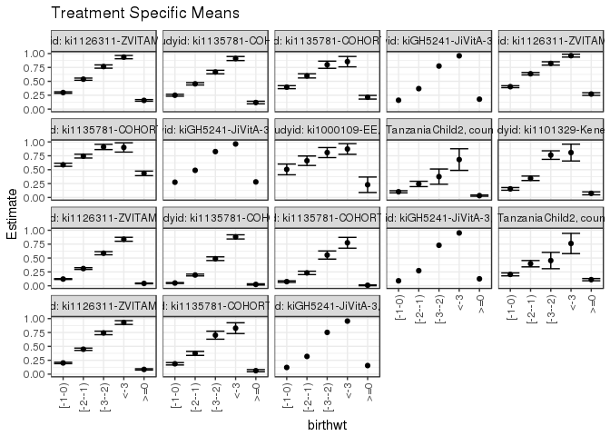

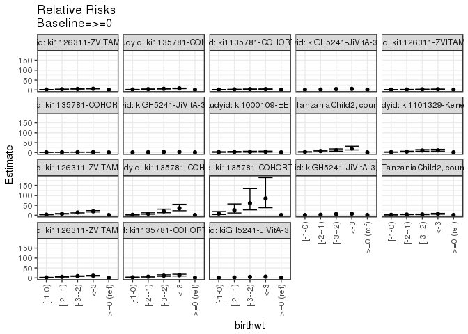

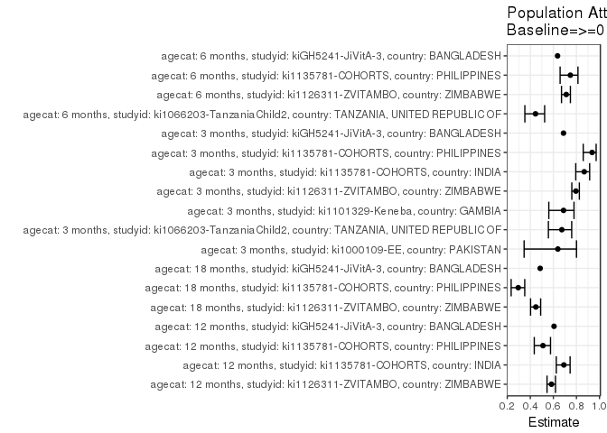

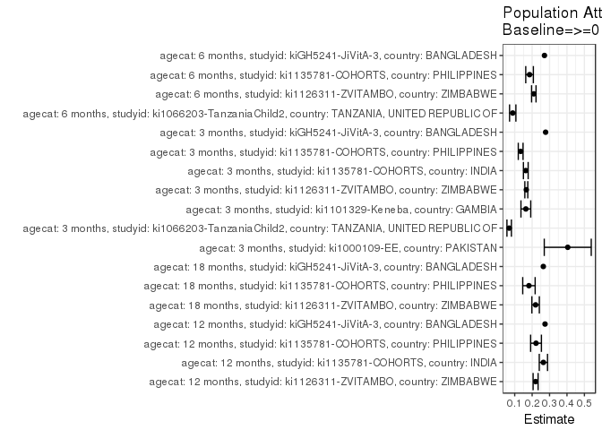

## Results Table

### Parameter: TSM

| agecat | studyid | country | intervention_level | baseline_level | estimate | ci_lower | ci_upper |
| --- | --- | --- | --- | --- | --- | --- | --- |
| 3 months | ki1000109-EE | PAKISTAN | >=0 | NA | 0.2285714 | 0.0892714 | 0.3678715 |
| 3 months | ki1000109-EE | PAKISTAN | <-3 | NA | 0.8723404 | 0.7768088 | 0.9678720 |
| 3 months | ki1000109-EE | PAKISTAN | [-3–2) | NA | 0.8082192 | 0.7177851 | 0.8986533 |
| 3 months | ki1000109-EE | PAKISTAN | [-2–1) | NA | 0.6610169 | 0.5754944 | 0.7465395 |
| 3 months | ki1000109-EE | PAKISTAN | [-1-0) | NA | 0.5048544 | 0.4081698 | 0.6015390 |
| 3 months | ki1066203-TanzaniaChild2 | TANZANIA, UNITED REPUBLIC OF | >=0 | NA | 0.0331384 | 0.0221834 | 0.0440934 |
| 3 months | ki1066203-TanzaniaChild2 | TANZANIA, UNITED REPUBLIC OF | <-3 | NA | 0.6818182 | 0.4871475 | 0.8764888 |
| 3 months | ki1066203-TanzaniaChild2 | TANZANIA, UNITED REPUBLIC OF | [-3–2) | NA | 0.3750000 | 0.2380144 | 0.5119856 |
| 3 months | ki1066203-TanzaniaChild2 | TANZANIA, UNITED REPUBLIC OF | [-2–1) | NA | 0.2434211 | 0.1951697 | 0.2916724 |
| 3 months | ki1066203-TanzaniaChild2 | TANZANIA, UNITED REPUBLIC OF | [-1-0) | NA | 0.1023785 | 0.0832677 | 0.1214892 |
| 3 months | ki1101329-Keneba | GAMBIA | >=0 | NA | 0.0742706 | 0.0477953 | 0.1007458 |
| 3 months | ki1101329-Keneba | GAMBIA | <-3 | NA | 0.8076923 | 0.6561635 | 0.9592211 |
| 3 months | ki1101329-Keneba | GAMBIA | [-3–2) | NA | 0.7627119 | 0.6859337 | 0.8394900 |
| 3 months | ki1101329-Keneba | GAMBIA | [-2–1) | NA | 0.3450185 | 0.3049874 | 0.3850495 |
| 3 months | ki1101329-Keneba | GAMBIA | [-1-0) | NA | 0.1543779 | 0.1303353 | 0.1784205 |
| 3 months | ki1126311-ZVITAMBO | ZIMBABWE | >=0 | NA | 0.0429238 | 0.0359174 | 0.0499302 |
| 3 months | ki1126311-ZVITAMBO | ZIMBABWE | <-3 | NA | 0.8373786 | 0.8017446 | 0.8730127 |
| 3 months | ki1126311-ZVITAMBO | ZIMBABWE | [-3–2) | NA | 0.5866441 | 0.5585820 | 0.6147063 |
| 3 months | ki1126311-ZVITAMBO | ZIMBABWE | [-2–1) | NA | 0.3100798 | 0.2944933 | 0.3256663 |
| 3 months | ki1126311-ZVITAMBO | ZIMBABWE | [-1-0) | NA | 0.1217241 | 0.1133092 | 0.1301391 |
| 3 months | ki1135781-COHORTS | INDIA | >=0 | NA | 0.0250000 | 0.0138994 | 0.0361006 |
| 3 months | ki1135781-COHORTS | INDIA | <-3 | NA | 0.8802817 | 0.8425234 | 0.9180400 |
| 3 months | ki1135781-COHORTS | INDIA | [-3–2) | NA | 0.4878049 | 0.4544146 | 0.5211952 |
| 3 months | ki1135781-COHORTS | INDIA | [-2–1) | NA | 0.1945060 | 0.1781750 | 0.2108370 |
| 3 months | ki1135781-COHORTS | INDIA | [-1-0) | NA | 0.0500808 | 0.0414890 | 0.0586726 |
| 3 months | ki1135781-COHORTS | PHILIPPINES | >=0 | NA | 0.0091743 | 0.0018660 | 0.0164826 |
| 3 months | ki1135781-COHORTS | PHILIPPINES | <-3 | NA | 0.7746479 | 0.6774461 | 0.8718496 |
| 3 months | ki1135781-COHORTS | PHILIPPINES | [-3–2) | NA | 0.5536723 | 0.4804258 | 0.6269188 |
| 3 months | ki1135781-COHORTS | PHILIPPINES | [-2–1) | NA | 0.2323651 | 0.2015748 | 0.2631555 |
| 3 months | ki1135781-COHORTS | PHILIPPINES | [-1-0) | NA | 0.0752533 | 0.0613428 | 0.0891637 |

[output cut: 60 more lines]

### Parameter: E(Y)

| agecat | studyid | country | intervention_level | baseline_level | estimate | ci_lower | ci_upper |
| --- | --- | --- | --- | --- | --- | --- | --- |
| 3 months | ki1000109-EE | PAKISTAN | NA | NA | 0.6329787 | 0.5841953 | 0.6817622 |
| 3 months | ki1066203-TanzaniaChild2 | TANZANIA, UNITED REPUBLIC OF | NA | NA | 0.1013942 | 0.0892314 | 0.1135569 |
| 3 months | ki1101329-Keneba | GAMBIA | NA | NA | 0.2382185 | 0.2192133 | 0.2572237 |
| 3 months | ki1126311-ZVITAMBO | ZIMBABWE | NA | NA | 0.2095333 | 0.2027900 | 0.2162767 |
| 3 months | ki1135781-COHORTS | INDIA | NA | NA | 0.1886110 | 0.1791995 | 0.1980226 |
| 3 months | ki1135781-COHORTS | PHILIPPINES | NA | NA | 0.1433322 | 0.1308057 | 0.1558588 |
| 3 months | kiGH5241-JiVitA-3 | BANGLADESH | NA | NA | 0.4031944 | NA | NA |
| 6 months | ki1066203-TanzaniaChild2 | TANZANIA, UNITED REPUBLIC OF | NA | NA | 0.1991852 | 0.1825264 | 0.2158439 |
| 6 months | ki1126311-ZVITAMBO | ZIMBABWE | NA | NA | 0.2945523 | 0.2851695 | 0.3039350 |
| 6 months | ki1135781-COHORTS | PHILIPPINES | NA | NA | 0.2478261 | 0.2317157 | 0.2639364 |
| 6 months | kiGH5241-JiVitA-3 | BANGLADESH | NA | NA | 0.4254386 | NA | NA |
| 12 months | ki1126311-ZVITAMBO | ZIMBABWE | NA | NA | 0.3769701 | 0.3675424 | 0.3863977 |
| 12 months | ki1135781-COHORTS | INDIA | NA | NA | 0.3829686 | 0.3709697 | 0.3949675 |
| 12 months | ki1135781-COHORTS | PHILIPPINES | NA | NA | 0.4361428 | 0.4174927 | 0.4547929 |
| 12 months | kiGH5241-JiVitA-3 | BANGLADESH | NA | NA | 0.4524409 | NA | NA |
| 18 months | ki1126311-ZVITAMBO | ZIMBABWE | NA | NA | 0.4911870 | 0.4796882 | 0.5026858 |
| 18 months | ki1135781-COHORTS | PHILIPPINES | NA | NA | 0.6152065 | 0.5964685 | 0.6339445 |
| 18 months | kiGH5241-JiVitA-3 | BANGLADESH | NA | NA | 0.5440713 | NA | NA |

### Parameter: RR

| agecat | studyid | country | intervention_level | baseline_level | estimate | ci_lower | ci_upper |
| --- | --- | --- | --- | --- | --- | --- | --- |
| 3 months | ki1000109-EE | PAKISTAN | >=0 | >=0 | 1.0000000 | 1.000000 | 1.000000 |
| 3 months | ki1000109-EE | PAKISTAN | <-3 | >=0 | 3.8164894 | 2.054705 | 7.088896 |
| 3 months | ki1000109-EE | PAKISTAN | [-3–2) | >=0 | 3.5359589 | 1.902864 | 6.570624 |
| 3 months | ki1000109-EE | PAKISTAN | [-2–1) | >=0 | 2.8919492 | 1.551017 | 5.392183 |
| 3 months | ki1000109-EE | PAKISTAN | [-1-0) | >=0 | 2.2087379 | 1.166027 | 4.183887 |
| 3 months | ki1066203-TanzaniaChild2 | TANZANIA, UNITED REPUBLIC OF | >=0 | >=0 | 1.0000000 | 1.000000 | 1.000000 |
| 3 months | ki1066203-TanzaniaChild2 | TANZANIA, UNITED REPUBLIC OF | <-3 | >=0 | 20.5748663 | 13.293254 | 31.845109 |
| 3 months | ki1066203-TanzaniaChild2 | TANZANIA, UNITED REPUBLIC OF | [-3–2) | >=0 | 11.3161765 | 6.914084 | 18.521016 |
| 3 months | ki1066203-TanzaniaChild2 | TANZANIA, UNITED REPUBLIC OF | [-2–1) | >=0 | 7.3455882 | 4.996021 | 10.800128 |
| 3 months | ki1066203-TanzaniaChild2 | TANZANIA, UNITED REPUBLIC OF | [-1-0) | >=0 | 3.0894215 | 2.113485 | 4.516013 |
| 3 months | ki1101329-Keneba | GAMBIA | >=0 | >=0 | 1.0000000 | 1.000000 | 1.000000 |
| 3 months | ki1101329-Keneba | GAMBIA | <-3 | >=0 | 10.8750000 | 7.269169 | 16.269483 |
| 3 months | ki1101329-Keneba | GAMBIA | [-3–2) | >=0 | 10.2693705 | 7.090489 | 14.873441 |
| 3 months | ki1101329-Keneba | GAMBIA | [-2–1) | >=0 | 4.6454270 | 3.193143 | 6.758229 |
| 3 months | ki1101329-Keneba | GAMBIA | [-1-0) | >=0 | 2.0785879 | 1.408722 | 3.066985 |
| 3 months | ki1126311-ZVITAMBO | ZIMBABWE | >=0 | >=0 | 1.0000000 | 1.000000 | 1.000000 |
| 3 months | ki1126311-ZVITAMBO | ZIMBABWE | <-3 | >=0 | 19.5084941 | 16.480290 | 23.093121 |
| 3 months | ki1126311-ZVITAMBO | ZIMBABWE | [-3–2) | >=0 | 13.6671069 | 11.529376 | 16.201207 |
| 3 months | ki1126311-ZVITAMBO | ZIMBABWE | [-2–1) | >=0 | 7.2239604 | 6.089768 | 8.569392 |
| 3 months | ki1126311-ZVITAMBO | ZIMBABWE | [-1-0) | >=0 | 2.8358194 | 2.375163 | 3.385819 |
| 3 months | ki1135781-COHORTS | INDIA | >=0 | >=0 | 1.0000000 | 1.000000 | 1.000000 |
| 3 months | ki1135781-COHORTS | INDIA | <-3 | >=0 | 35.2112676 | 22.539634 | 55.006809 |
| 3 months | ki1135781-COHORTS | INDIA | [-3–2) | >=0 | 19.5121951 | 12.450623 | 30.578851 |
| 3 months | ki1135781-COHORTS | INDIA | [-2–1) | >=0 | 7.7802393 | 4.951521 | 12.224956 |
| 3 months | ki1135781-COHORTS | INDIA | [-1-0) | >=0 | 2.0032310 | 1.244516 | 3.224493 |
| 3 months | ki1135781-COHORTS | PHILIPPINES | >=0 | >=0 | 1.0000000 | 1.000000 | 1.000000 |
| 3 months | ki1135781-COHORTS | PHILIPPINES | <-3 | >=0 | 84.4366197 | 37.696744 | 189.128875 |
| 3 months | ki1135781-COHORTS | PHILIPPINES | [-3–2) | >=0 | 60.3502825 | 26.914090 | 135.325275 |
| 3 months | ki1135781-COHORTS | PHILIPPINES | [-2–1) | >=0 | 25.3278008 | 11.294902 | 56.795311 |
| 3 months | ki1135781-COHORTS | PHILIPPINES | [-1-0) | >=0 | 8.2026049 | 3.620749 | 18.582544 |

[output cut: 60 more lines]

### Parameter: PAR

| agecat | studyid | country | intervention_level | baseline_level | estimate | ci_lower | ci_upper |
| --- | --- | --- | --- | --- | --- | --- | --- |
| 3 months | ki1000109-EE | PAKISTAN | >=0 | NA | 0.4044073 | 0.2696045 | 0.5392101 |
| 3 months | ki1066203-TanzaniaChild2 | TANZANIA, UNITED REPUBLIC OF | >=0 | NA | 0.0682558 | 0.0554533 | 0.0810583 |
| 3 months | ki1101329-Keneba | GAMBIA | >=0 | NA | 0.1639480 | 0.1358688 | 0.1920272 |
| 3 months | ki1126311-ZVITAMBO | ZIMBABWE | >=0 | NA | 0.1666095 | 0.1581240 | 0.1750951 |
| 3 months | ki1135781-COHORTS | INDIA | >=0 | NA | 0.1636110 | 0.1500617 | 0.1771603 |
| 3 months | ki1135781-COHORTS | PHILIPPINES | >=0 | NA | 0.1341579 | 0.1204797 | 0.1478361 |
| 3 months | kiGH5241-JiVitA-3 | BANGLADESH | >=0 | NA | 0.2773902 | NA | NA |
| 6 months | ki1066203-TanzaniaChild2 | TANZANIA, UNITED REPUBLIC OF | >=0 | NA | 0.0886533 | 0.0705035 | 0.1068032 |
| 6 months | ki1126311-ZVITAMBO | ZIMBABWE | >=0 | NA | 0.2096156 | 0.1968759 | 0.2223553 |
| 6 months | ki1135781-COHORTS | PHILIPPINES | >=0 | NA | 0.1852203 | 0.1633636 | 0.2070770 |
| 6 months | kiGH5241-JiVitA-3 | BANGLADESH | >=0 | NA | 0.2707425 | NA | NA |
| 12 months | ki1126311-ZVITAMBO | ZIMBABWE | >=0 | NA | 0.2199065 | 0.2055620 | 0.2342509 |
| 12 months | ki1135781-COHORTS | INDIA | >=0 | NA | 0.2646013 | 0.2408881 | 0.2883144 |
| 12 months | ki1135781-COHORTS | PHILIPPINES | >=0 | NA | 0.2223381 | 0.1913574 | 0.2533188 |
| 12 months | kiGH5241-JiVitA-3 | BANGLADESH | >=0 | NA | 0.2740625 | NA | NA |
| 18 months | ki1126311-ZVITAMBO | ZIMBABWE | >=0 | NA | 0.2199291 | 0.1985569 | 0.2413013 |
| 18 months | ki1135781-COHORTS | PHILIPPINES | >=0 | NA | 0.1816400 | 0.1459670 | 0.2173131 |
| 18 months | kiGH5241-JiVitA-3 | BANGLADESH | >=0 | NA | 0.2641731 | NA | NA |

### Parameter: PAF

| agecat | studyid | country | intervention_level | baseline_level | estimate | ci_lower | ci_upper |
| --- | --- | --- | --- | --- | --- | --- | --- |
| 3 months | ki1000109-EE | PAKISTAN | >=0 | NA | 0.6388956 | 0.3462092 | 0.8005533 |
| 3 months | ki1066203-TanzaniaChild2 | TANZANIA, UNITED REPUBLIC OF | >=0 | NA | 0.6731725 | 0.5568461 | 0.7589637 |
| 3 months | ki1101329-Keneba | GAMBIA | >=0 | NA | 0.6882251 | 0.5604533 | 0.7788550 |
| 3 months | ki1126311-ZVITAMBO | ZIMBABWE | >=0 | NA | 0.7951457 | 0.7599245 | 0.8251997 |
| 3 months | ki1135781-COHORTS | INDIA | >=0 | NA | 0.8674521 | 0.7941771 | 0.9146404 |
| 3 months | ki1135781-COHORTS | PHILIPPINES | >=0 | NA | 0.9359927 | 0.8589263 | 0.9709589 |
| 3 months | kiGH5241-JiVitA-3 | BANGLADESH | >=0 | NA | 0.6879814 | NA | NA |
| 6 months | ki1066203-TanzaniaChild2 | TANZANIA, UNITED REPUBLIC OF | >=0 | NA | 0.4450801 | 0.3527128 | 0.5242667 |
| 6 months | ki1126311-ZVITAMBO | ZIMBABWE | >=0 | NA | 0.7116415 | 0.6704787 | 0.7476624 |
| 6 months | ki1135781-COHORTS | PHILIPPINES | >=0 | NA | 0.7473803 | 0.6584027 | 0.8131814 |
| 6 months | kiGH5241-JiVitA-3 | BANGLADESH | >=0 | NA | 0.6363843 | NA | NA |
| 12 months | ki1126311-ZVITAMBO | ZIMBABWE | >=0 | NA | 0.5833526 | 0.5450542 | 0.6184270 |
| 12 months | ki1135781-COHORTS | INDIA | >=0 | NA | 0.6909215 | 0.6252583 | 0.7450791 |
| 12 months | ki1135781-COHORTS | PHILIPPINES | >=0 | NA | 0.5097828 | 0.4342839 | 0.5752058 |
| 12 months | kiGH5241-JiVitA-3 | BANGLADESH | >=0 | NA | 0.6057422 | NA | NA |
| 18 months | ki1126311-ZVITAMBO | ZIMBABWE | >=0 | NA | 0.4477502 | 0.4023885 | 0.4896688 |
| 18 months | ki1135781-COHORTS | PHILIPPINES | >=0 | NA | 0.2952505 | 0.2338702 | 0.3517132 |
| 18 months | kiGH5241-JiVitA-3 | BANGLADESH | >=0 | NA | 0.4855486 | NA | NA |